# Arranjo de gráficos em ggplot

WHSP

2018-01-17

O arranjo de gráficos com ggplot tem sido um problema com soluções ainda em desenvolvimento. Neste tutorial vamos ver três pacotes que oferecem soluções diferentes.

O primero é o pacote recentemente criado (novembro 2017), denominado “patchwork”, os outros dois são o “grid” e o “cowplot”, que oferecem soluções mais elaboradas, porém exigem mais conhecimento.

#### Pacote “patchwork”

Um novo pacote, ainda em desenvolvimento, foi criado por Thomas Lin Pedersen https://github.com/thomasp85/patchwork com o intuito de facilitar o arranjo de gráficos com ggplot.

Na sequência vamos apresentar a tradução do post de apresentação do pacote feito pelo autor (com pequenas modificações).

Exemplo

O uso de patchwork é simples como colocar os gráficos juntos!

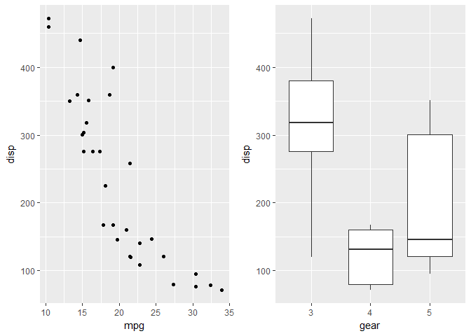

```r
library(ggplot2)
library(patchwork)
mtcars$gear <- as.factor(mtcars$gear) # added 20180117
mtcars$carb <- as.factor(mtcars$carb) # added 20180117
p1 <- ggplot(mtcars) + geom_point(aes(mpg, disp))
p2 <- ggplot(mtcars) + geom_boxplot(aes(gear, disp, group = gear))

p1 + p2
```

Pode-se ainda colocar os gráficos juntos também usando o mesmo código ggplot:

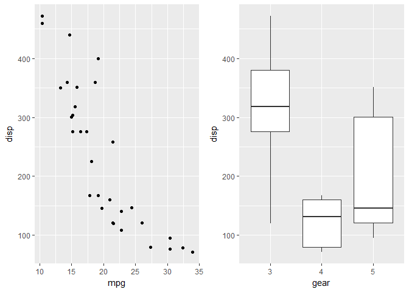

```r
ggplot(mtcars) +
  geom_point(aes(mpg, disp)) +
  ggplot(mtcars) +
  geom_boxplot(aes(gear, disp, group = gear))
```

Diferentes formatações de apresentação podem ser feitas, adicionando a função `plot_layout()`. Assim definimos as dimensôes e o espaço das diferentes linhas e colunas.

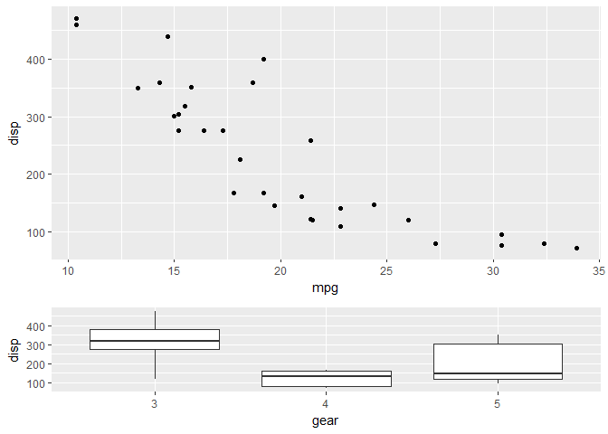

```r
p1 + p2 + plot_layout(ncol = 1, heights = c(3, 1))
```

Precisando de adicionar um espaço entre os gráfics, use `plot_spacer()` para preencher uma célula com espaço em branco (por enquanto sem possibilidade de definir o tamanho).

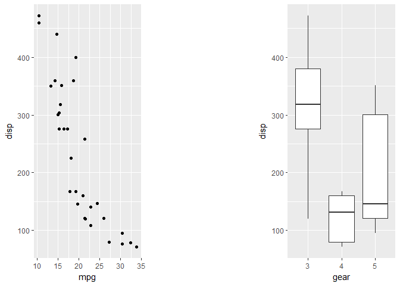

```r
p1 + plot_spacer() + p2
```

Podem ser feitos gráficos aninhados, envolvendo parte dos mesmos em parentesis (neste caso a apariência é modificada para os diferentes níveis desejados)

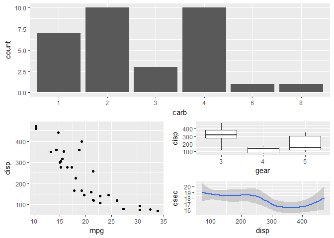

```r
p3 <- ggplot(mtcars) + geom_smooth(aes(disp, qsec))
p4 <- ggplot(mtcars) + geom_bar(aes(carb))

p4 + {
  p1 + {
    p2 +
      p3 +
      plot_layout(ncol = 1)
  }
} +
  plot_layout(ncol = 1)
```

Funções avançadas

Além de adicionar gráficos e apariências, patchwork define alguns outros operadores que podem ser de interesse. Podemos querer adicionar “+” mais colocar a o lado direito e o esquerdo do gráfico no mesmo nível (diferente de colocar de colocá-los aninhados) Observe:

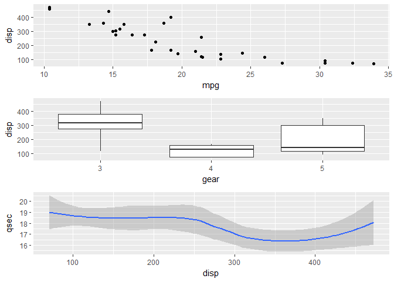

```r
# Todos os gráficos na mesma extensão...
p1 + p2 + p3 + plot_layout(ncol = 1) # posso usar nrow também
```

Isto é basicamente o mesmo que sem usar os parentêsis (como se fosse pura aritmética), os gráficos se adicionam no mesmo nível, mas agora olhe o seguinte:

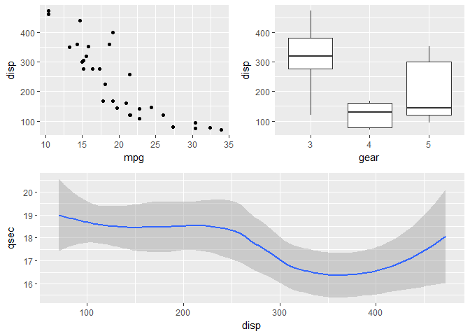

```r
# dois primeiros gráficos no mesmo nível e o terceiro num segundo nível
p1 + p2 - p3 + plot_layout(ncol = 1)
```

*Uma note referente a semântica do pacote. Se “-” fosse lido como substraindo terá pouco sentido já que estariamos retirando gráficos, pense melhor que apenas um separador.*

Para colocar os gráficos um encima de outros ou do lado, patchwork tem tanto o operador “|” como “/” para dividir o espaço na horizontal ou na vertical respectivamente. Assim podemos combinar os gráficos numa sintaxe muito legível.

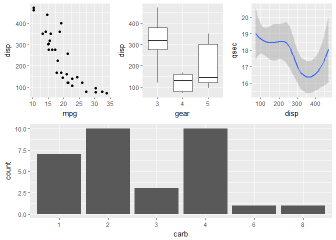

```r
(p1 | p2 | p3) /
      p4
```

Temos ainda dois operadores adicionais que tem um propósito levemente diferente, com a finalidade de reducir código. Pense no caso em que deseja cambiar o tema de todos os seus gráficos. Em vez de modificar sua apariência em forma individual, pode usar “&” ou “*" para adicionar elementos a todos os sub-gráficos de uma janela.

Os dois diferem em que “*" opera apenas no nível em que se encontra e “&” opera sobre todos os gráficos.

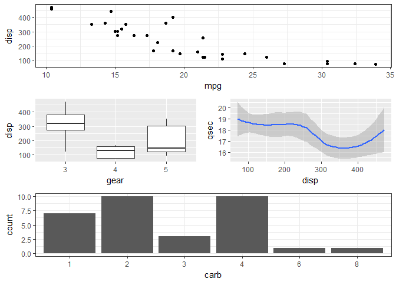

```r
(p1 + (p2 + p3) + p4 + plot_layout(ncol = 1)) * theme_bw()
```

enquanto “&” trabalha em todos os níveis:

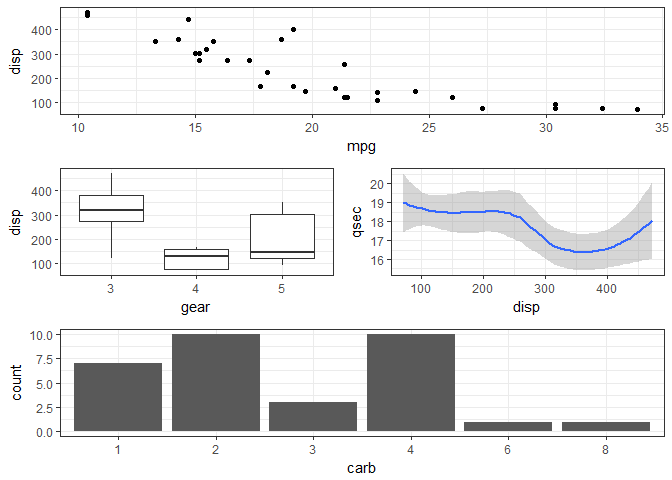

```r
p1 + (p2 + p3) + p4 + plot_layout(ncol = 1) & theme_bw()
```

*Note que o parentesis é requerido no caso anterior devido a que “*” tem preferência. O último caso apresentado é o mais comum e deve ser o de mais fácil uso.*

Mais funcionalidade vão ir sendo adicionadas…

#### O pacote “grid”

O seguinte exemplo foi postado no grupo de ggplot2 do google (ggplot2@googlegroups.com), sendo uma das formas de arranjar vários gráficos de ggplot numa janela común.

Vamos plotar numa janela 4 gráficos, usando funções dos pacotes “grid” e “grid.Extra”. Os dados são da base de dados *mtcars*.

##### Os gráficos que se desejam plotar…

```r
#
gplot1 <- ggplot(mtcars, aes(x= disp, y = mpg)) +
  geom_point()

#
gplot2 <- ggplot(mtcars, aes(x= disp, y = mpg)) +
  geom_point()                                  +
  geom_smooth(method = "lm")

#
gplot3 <- ggplot(mtcars, aes(x= disp, y = mpg, colour = as.factor(am))) +
  geom_point()                                                          +
  geom_smooth(method = "lm", se = FALSE)                                +
  theme_light()

gplot4 <- ggplot(mtcars, aes(x= disp, y = mpg, colour = as.factor(am), size = wt)) +
  geom_point()                                                                     +
  geom_smooth(method = "lm", se = FALSE)                                           +
  theme_light()
```

##### preparando os títulos comuns, funções do pacote “grid”

Usando a função *textGrob*, vamos criar três legendas, uma principal no topo da janela e duas para os eixos x e y.

```r
top    <- textGrob("MTCARS - Análise de rendimento de carros",
                   gp = gpar(fontface = "bold", cex = 1.2))

bottom <- textGrob("Deslocamento em polegadas cúbicas",
                   gp = gpar(fontface = "bold", cex = 1.2), hjust = 0.5)

left   <- textGrob("Milhas por galão (US)",
                   gp = gpar(fontface = "bold", cex = 1.2), rot = 90)
```

```r
# preparando os gráficos individuais, função do pacote "gridExtra"
GPLOT1<-arrangeGrob(gplot1, top = textGrob("Distribuição",
                                   x          = unit(0.17, "npc"),
                                   y          = unit(0.30, "npc"),
                                   just       = c("left", "top"),
                                   gp         = gpar(col = "black",
                                   fontsize   = 10,
                                   fontface   = "bold",
                                   fontfamily = "Times Roman")))

GPLOT2<-arrangeGrob(gplot2, top = textGrob("Regressão linear",
                                   x          = unit(0.17, "npc"),
                                   y          = unit(0.30, "npc"),
                                   just       = c("left", "top"),
                                   gp         = gpar(col = "black",
                                   fontsize   = 10,
                                   fontface   = "bold",
                                   fontfamily = "Times Roman")))

GPLOT3<-arrangeGrob(gplot3, top = textGrob("Regressão linear por tipo de marcha",
                                   x          = unit(0.17, "npc"),
                                   y          = unit(0.30, "npc"),
                                   just       = c("left", "top"),
                                   gp         = gpar(col = "black",
                                   fontsize   = 10,
                                   fontface   = "bold",
                                   fontfamily = "Times Roman")))

GPLOT4<-arrangeGrob(gplot4, top = textGrob("Regressão linear por tipo de marcha e peso",
                                   x          = unit(0.17, "npc"),
                                   y          = unit(0.30, "npc"),
                                   just       =c("left","top"),
                                   gp         =gpar(col = "black",
                                   fontsize   = 10,
                                   fontface   = "bold",
                                   fontfamily  = "Times Roman")))
```

##### ordenando e graficando, função do pacote “gridExtra”

```r
grid.arrange(GPLOT1,
             GPLOT2,
             GPLOT3,
             GPLOT4,
             ncol   = 2,
             bottom = bottom,
             left   = left,
             top    = top)
```

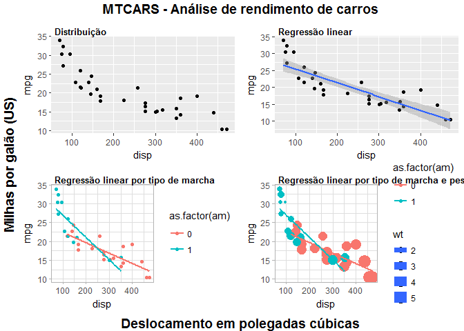

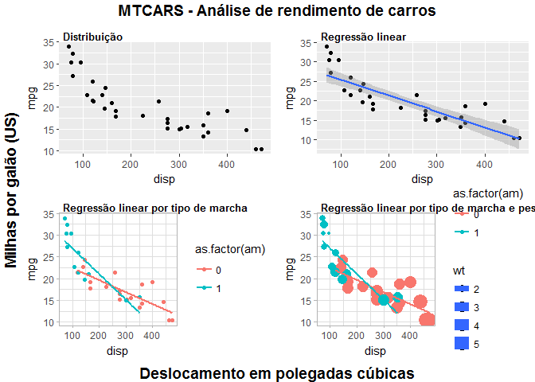

#### Pacote “cowplot”

Veja o tutorial de cowplot

```r
library(cowplot)
plot_grid(GPLOT1,
          GPLOT2,
          GPLOT3,
          GPLOT4,
          labels = c("(A)",
                     "(B)",
                     "(C)",
                     "(D)"),
          ncol   = 2,
          nrow   = 2)
```

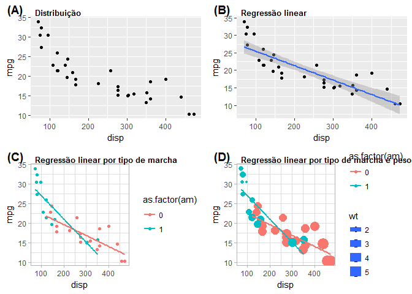

FIM DO TUTORIAL

[figure not shown]

#### Pacote “patchwork”

Um novo pacote, ainda em desenvolvimento, foi criado por Thomas Lin Pedersen https://github.com/thomasp85/patchwork com o intuito de facilitar o arranjo de gráficos com ggplot.

Na sequência vamos apresentar a tradução do post de apresentação do pacote feito pelo autor.

Exemplo

O uso de patchwork é simples como colocar os gráficos juntos!

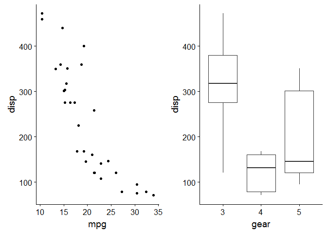

```r
library(ggplot2)
library(patchwork)
mtcars$gear <- as.factor(mtcars$gear) # added 20180117
mtcars$carb <- as.factor(mtcars$carb) # added 20180117
p1 <- ggplot(mtcars) + geom_point(aes(mpg, disp))
p2 <- ggplot(mtcars) + geom_boxplot(aes(gear, disp, group = gear))

p1 + p2
```

Pode-se ainda colocar os gráficos juntos também usando o mesmo código ggplot:

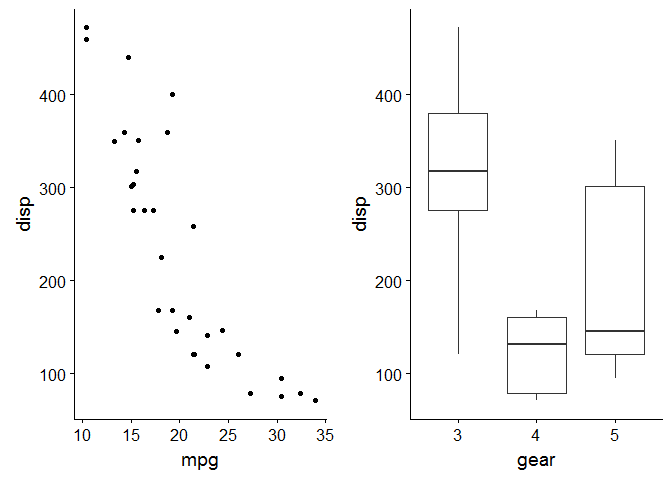

```r
ggplot(mtcars) +
  geom_point(aes(mpg, disp)) +
  ggplot(mtcars) +
  geom_boxplot(aes(gear, disp, group = gear))
```

Diferentes formatações de apresentação podem ser feitas, adicionando a função `plot_layout()`. Assim definimos as dimensôes e o espaço das diferentes linhas e colunas.

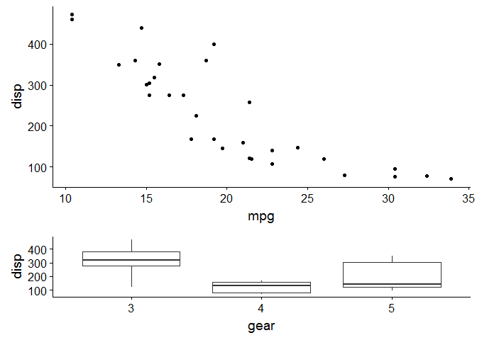

```r
p1 + p2 + plot_layout(ncol = 1, heights = c(3, 1))
```

f you need to add a bit of space between your plots you can use plot_spacer() to fill a cell in the grid with nothing

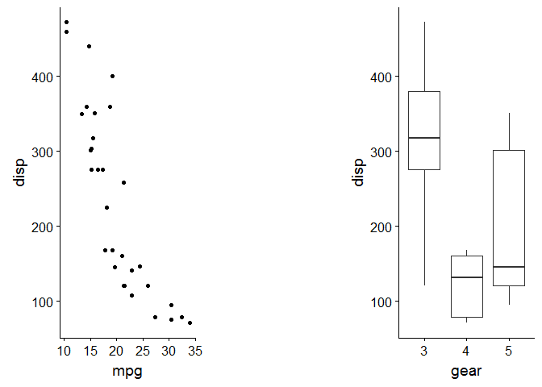

```r
p1 + plot_spacer() + p2
```

You can make nested plots layout by wrapping part of the plots in parentheses - in these cases the layout is scoped to the different nesting levels

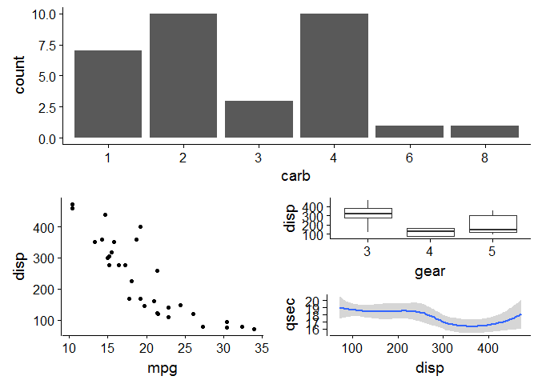

```r
p3 <- ggplot(mtcars) + geom_smooth(aes(disp, qsec))
p4 <- ggplot(mtcars) + geom_bar(aes(carb))

p4 + {
  p1 + {
    p2 +
      p3 +
      plot_layout(ncol = 1)
  }
} +
  plot_layout(ncol = 1)
```

Advanced features

In addition to adding plots and layouts together, patchwork defines some other operators that might be of interest. - will behave like + but put the left and right side in the same nesting level (as opposed to putting the right side into the left sides nesting level). Observe:

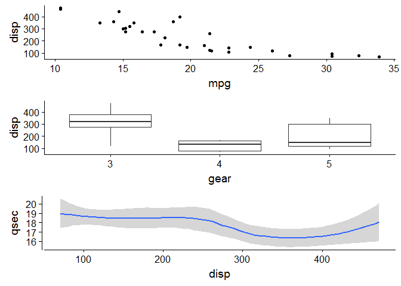

```r
p1 + p2 + p3 + plot_layout(ncol = 1)
```

this is basically the same as without braces (just like standard math arithmetic) - the plots are added sequentially to the same nesting level. Now look:

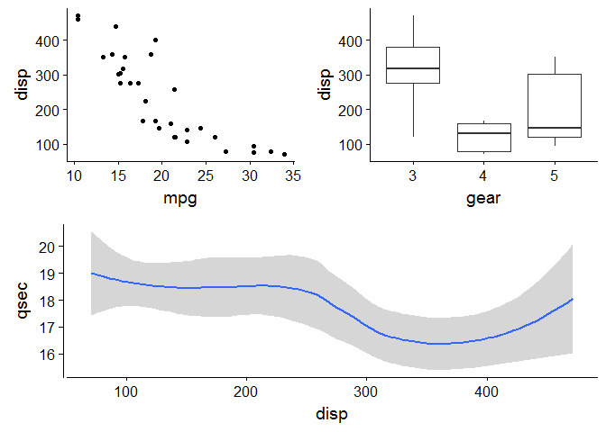

```r
p1 + p2 - p3 + plot_layout(ncol = 1)
```

Now p1 + p2 and p3 is on the same level…

*A note on semantics. If - is read as subtrack its use makes little sense as we are not removing plots. Think of it as a hyphen instead…*

Often you are interested in just putting plots besides or on top of each other. patchwork provides both | and / for horizontal and vertical layouts respectively. They can of course be combined for a very readable layout syntax:

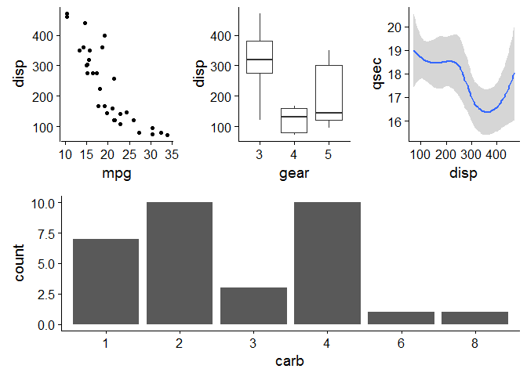

```r
(p1 | p2 | p3) /
      p4
```

There are two additional operators that are used for a slightly different purpose, namely to reduce code repetition. Consider the case where you want to change the theme for all plots in an assemble. Instead of modifying all plots individually you can use & or * to add elements to all subplots. The two differ in that * will only affect the plots on the current nesting level:

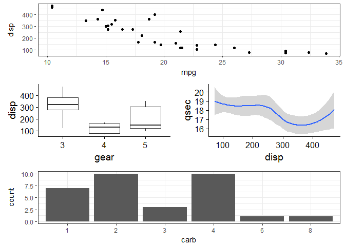

```r
(p1 + (p2 + p3) + p4 + plot_layout(ncol = 1)) * theme_bw()
```

whereas & will recurse into nested levels:

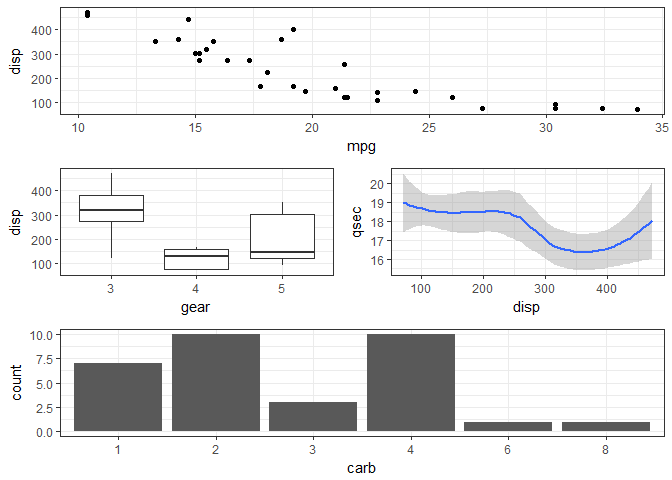

```r
p1 + (p2 + p3) + p4 + plot_layout(ncol = 1) & theme_bw()
```

*Note that parenthesis is required in the former case due to higher precedence of the * operator. The latter case is the most common so it has deserved the easiest use.*

This is all it does for now, but stay tuned as more functionality is added, such as collapsing guides, etc…